# Tree-Based Methods

*Empirical Methods in Economics and Business*

Zhiyuan Chen

**Renmin Business School**

May 2025

## Roadmap

- Use **basic decision trees** to model relationships between predictors and an outcome
- Compare and contrast tree-based models with other model types
- Use **tree-based ensemble methods** to build (better!) predictive models
- Compare and contrast the various methods of building tree ensembles: **bagging, boosting and random forests**

## Introduction to Tree-based Methods

- Involve **stratifying** or **segmenting** the predictor space into a number of simple regions
- Are simple and useful for interpretation
- BUT, basic decision trees are NOT competitive with the best supervised learning approaches in terms of prediction accuracy
- Thus, we also discuss **bagging**, **random forests**, and **boosting** (i.e., tree-based **ensemble methods**) to grow multiple trees which are then combined to yield a single consensus prediction
- These can result in dramatic improvements in prediction accuracy (but some loss of interpretability)
- Can be applied to both regression and classification

## Regression Trees

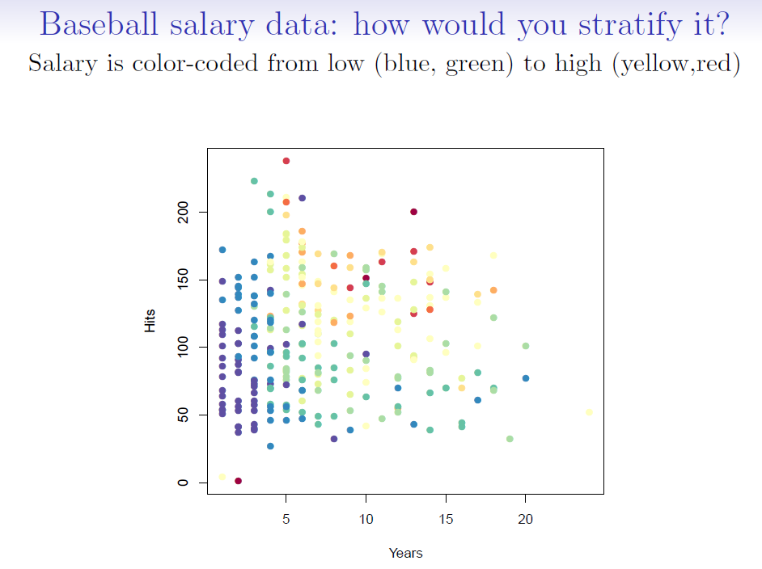

### Example: A Regression Tree for Baseball Hitters

- For the Hitters data, a regression tree for predicting the log salary of a baseball player based on:
  1. number of years that he has played in the major leagues
  2. number of hits that he made in the previous year

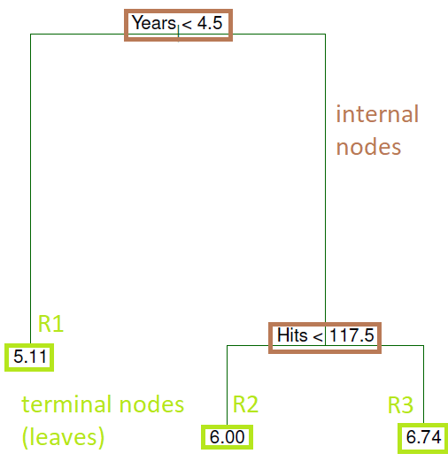

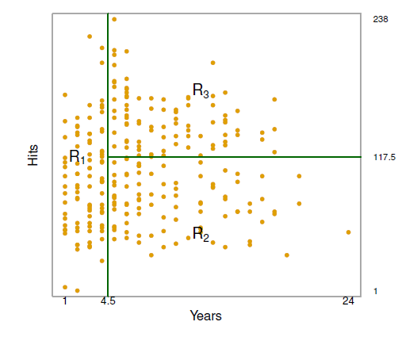

- Overall, the tree stratifies or segments the players into three regions of predictor space:
  - $R_1 = \{X | Years< 4.5\}$
  - $R_2 = \{X | Years>=4.5, Hits<117.5\}$
  - $R_3 = \{X | Years>=4.5, Hits>=117.5\}$

where $R_1$, $R_2$, and $R_3$ are **terminal nodes** (leaves) and green lines (where the predictor space is split) are the **internal nodes**

- The number in each leaf/terminal node is the mean of the response for the observations that fall there

#### Interpretation of the tree

- `Years` is the most important factor in determining `Salary`: *players with less experience earn lower salaries than more experienced players*.
- Given that a player is less experienced, the number of Hits that he made in the previous year seems to play little role in his Salary
- But among players who have been in the major leagues for 5 or more years, the number of Hits made in the previous year does affect Salary: players who made more Hits last year tend to have higher salaries
- This is surely an over-simplification, but compared to a regression model, it is **easy to display, interpret and explain**

## Tree-building Process (Regression Trees)

power is important

regions that best predict $y$

- **Regression Tree** is a two-step process:
  1. Divide the predictor space $(X_1, X_2,\cdots, X_p)$ into $J$ distinct and exclusive regions, $R_1,R_2,\cdots, R_J$
     - Regions can be ANY shape
  2. For every observation in region $R_j$, we use the **mean of the response values** for the training observations $R_j$
- The goal is to find regions $\{R_j\}_{j=1}^J$ to **minimize**

$$ RSS= \sum_{j=1}^J\sum_{i\in R_j}(y_i-\hat{y}_{R_j})^2 $$

- Unfortunately, it is **computationally infeasible** to consider every possible partition of the feature space into $J$ boxes.

## Recursive binary splitting

So, take a top-down, greedy approach known as recursive binary splitting:

- **top-down** because it begins at the top of the tree and then successively splits the predictor space
- **greedy** because at each step of the tree-building process, the best split is made at that particular step, rather than looking ahead and picking a split that will lead to a better tree in some future step

## Recursive binary splitting (continued)

1. We first select the predictor $X_j$ and the cutpoint $s$ such that splitting the predictor space into the regions ${\{X|X_j<s\}}$ and ${\{X|X_j{\ge}s}\}$ leads to the greatest possible reduction in RSS
2. Repeat the process looking for the best predictor and **best cutpoint** to split data further (i.e., split one of the 2 previously identified regions - not the entire predictor space) minimizing the RSS within each of the resulting regions
3. Continue until a stopping criterion is reached, e.g., no region contains more than five observations
4. Again, we predict the response for a given test observation using the **mean of the training observations** in the region to which that test observation belongs

## But...

- The previous method may result in a tree that **overfits** the data. Why?
- Tree is too leafy (complex)
- A better strategy is to have a smaller tree with fewer splits, which will reduce variance and lead to better interpretation of results (at the cost of a little bias)
- So we will **prune the tree (剪枝)** after it has been built

### Pruning a tree

1. **Step 1**: Grow a very large tree $T_0$ as before
2. **Step 2**: Apply *cost-complexity pruning* to $T_0$ to obtain a sequence of BEST subtrees, as a function of $\alpha$

Cost complexity pruning **minimizes** $$\sum_{m=1}^{|T|}\sum_{x_i{\in}R_m}(y_i-\hat{y}_{R_m})^2 + \alpha|T|$$

where

- $\alpha$ $\geq$ 0 is the **tuning parameter (调参变量)**
- $|T|$ is the number of **terminal nodes** the sub tree $|T|$ holds
- $R_m$ is the rectangle/region (i.e., the subset of predictor space) corresponding to the $m$th terminal node
- $\hat{y}_{R_m}$ is the **mean** response for the training observations in $R_m$
- The tuning parameter $\alpha$ controls:
  - a trade-off between the subtree's complexity (the number of terminal nodes)
  - the subtree's fit to the training data
3. **Step 3**: Choose $\alpha$ using K-fold cross-validation
   - (3.1) repeat steps 1 and 2 for each $(K-1)/K$ fraction of training data
   - (3.2) average the results and pick $\alpha$ to minimize the average MSE
     - Recall that in **K-folds cross-validation**:

> **K-fold cross-validation**: Dividing the dataset into K roughly equal-sized subsets (called "folds"). The model is trained and tested K times, each time using a different fold as the validation set and the remaining $K−1$ folds as the training set. The model's performance is then averaged over the K trials.
- e.g., $K=5$, the model is estimated on 80% of the data five different times, the predictions are made for the remaining 20%, and the test MSEs are averaged
1. **Step 4**: Return to the subtree from **Step 2** that corresponds to the chosen value of $\alpha$

## Tree Pruning (Hitters Data)

- Results of fitting and pruning a regression tree on the Hitters data using 9 of the features
- Randomly divided the data set in half (132 observations in training, 131 observations in the test set)
- Built large regression tree on training data and varied $\alpha$ to create subtrees with different numbers of terminal nodes
- Finally, performed 6-fold cross-validation to estimate the cross-validated MSE of the trees as a function of $\alpha$

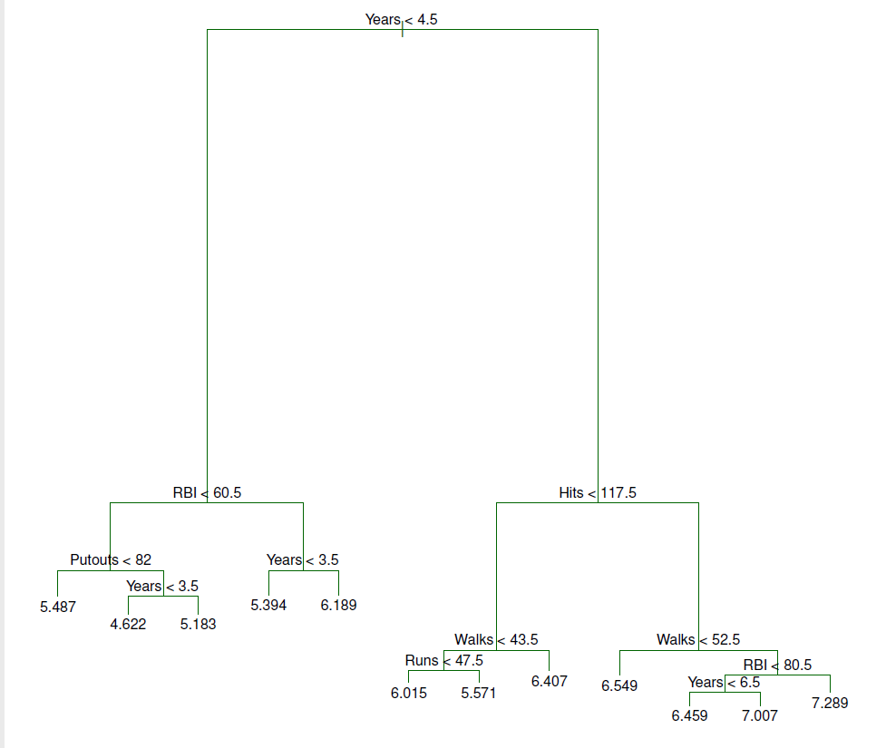

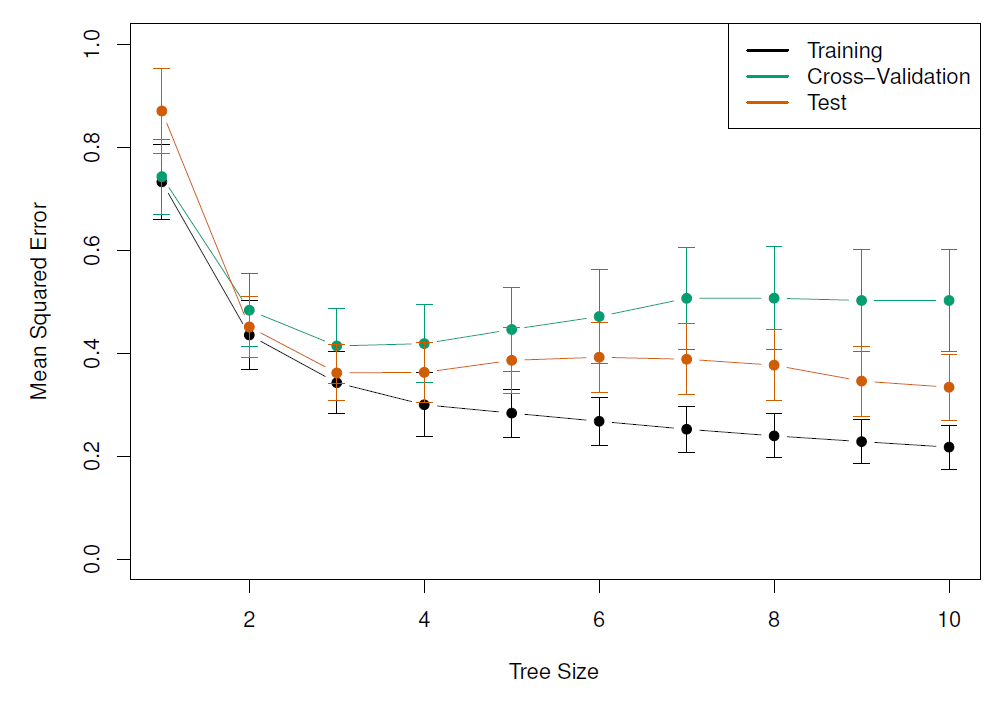

## Classification trees

- Very similar to a regression tree except it predicts a qualitative (vs quantitative) response
- We predict that each observation belongs to the **most commonly occurring class** of training observations in the region to which it belongs
- In the classification setting, RSS cannot be used as a criterion for making the binary splits
- A natural alternative to RSS is the classification **error rate**, i.e., the fraction of the training observations in that region that do not belong to the most common class:

$$E = 1 - \max_k(\hat{p}_{mk})$$

where $\hat{p}_{mk}$ is the **proportion of training observations** in the $m$ -th region that are from the $k$ -th class

- However, this error rate is unsuited for tree-based classification because $E$ does not change much as the tree grows (**lacks sensitivity**)

## Classification trees (continued)

- Two other measures are preferable
  - The **Gini Index** defined by $$G = \sum_{k=1}^{K}\hat{p}_{mk}(1-\hat{p}_{mk})$$ is a measure of total variance across the K classes
  - The Gini index takes on a small value if all of the $\hat{p}_{mk}$'s are close to 0 or 1
  - For this reason the Gini index is referred to as a measure of node **purity** - a small value indicates that a node contains predominantly observations from a single class
  - An alternative to the Gini index is **cross-entropy** given by

$$D = - \sum_{k=1}^{K}\hat{p}_{mk}\log(\hat{p}_{mk})$$

- The Gini index and cross-entropy are very similar numerically

### Example: classification tree (Heart data)

- Data contain a binary outcome HD (heart disease Y or N based on angiographic test) for 303 patients who presented with chest pain
- 13 predictors including Age, Sex, Chol (a cholesterol measurement), and other heart and lung function measurements
- Cross-validation yields a tree with six terminal nodes

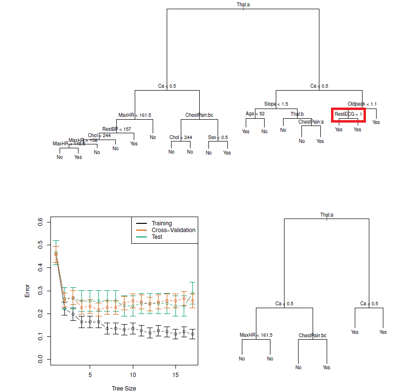

## Advantages/Disadvantages of decision trees

**Advantages**:

- Trees can be displayed graphically and are **very easy to explain** to people
- They mirror human decision-making
- Can handle qualitative predictors without the need for dummy variables

**Disadvantages**:

- They do not have the same level of predictive accuracy
- Can be very non-robust (i.e., a small change in the data can cause large change in the final estimated tree)
- To improve performance, we can use an **ensemble method (集成方法)**, which combines many simple 'buidling blocks' (i.e., regression or classification trees) to obtain a single and potentially very powerful model
- **Ensemble** methods include: bagging, random forests, boosting, and Bayesian additive regression trees

## Bagging (Bootstrap Aggregating, 自助聚合)

> **Bagging的核心思想**: 从训练集中有放回地多次采样（bootstrap）出不同的子数据集，在这些子集上分别训练多个模型，最后对它们的预测结果进行平均（回归）或投票（分类），从而得到更稳定、准确的预测结果。
- Also known as **bootstrap aggregating** is a general-purpose procedure for *reducing the variance* of a statistical learning method
- It's useful and frequently used in the context of decision trees
- Recall that given a set of $n$ independent observations $Z_1,..., Z_n$, each with variance $\sigma^2$, the variance of the mean $\bar{Z}$ of the observations is given by $\sigma^2/n$
- So, **averaging a set of observations** reduces variance
- But, this is not practical because we generally do not have access to multiple training sets!

## Bagging (continued)

- **Bootstrap**: take repeated samples from the single training set
- Generate $B$ different bootstrapped training data sets
- Then train our method on the $b$ th bootstrapped training set to get $\hat{f}^{*b}$, the prediction at a point $x$
- Average all the predictions to obtain $$\hat{f}_{bag}(x) = \frac{1}{B}\sum_{b=1}^B\hat{f}^{*b}(x)$$
- In the case of classification trees:
  - for each test observation:
    - record the class predicted by each of the $B$ trees
    - take a **majority vote**: *the overall prediction is the most commonly occurring class among the $B$ predictions*

> **NOTE**: the number of trees $B$ is not a critical parameter with bagging - a large $B$ will not lead to overfitting

## Out-of-bag error estimation

- It's pretty straightforward to estimate the test error of a bagged model:
  1. Because trees are repeatedly fit to bootstrapped subsets of observations, on average each bagged tree uses about 2/3 of the observations
  2. The leftover 1/3 not used to fit a given bagged tree are called **out-of-bag** (OOB) observations
  3. We can predict the response for the $i$th observation using each of the trees in which that observation was OOB. Gives around B/3 predictions for the $i$th observation (which we then average)
  4. This estimate is essentially the LOO cross-validation error for bagging (if $B$ is large)

## Variable importance measures

- Bagging results in improved accuracy over prediction using a single tree
- But, it can be difficult to interpret the resulting model:
  - we can't represent the statistical learning procedure using a single tree
  - it's not clear which variables are most important to the procedure (i.e., we have many trees each of which may give a differing view on the importance of a given predictor)
- So which predictors are important?
  - An overall summary of the importance of each predictor can be achieved by recording how much the average $RSS$ or Gini index **improves (or decreases)** when each tree is split over a given predictor (averaged over all $B$ trees)
    - a large value = important predictor

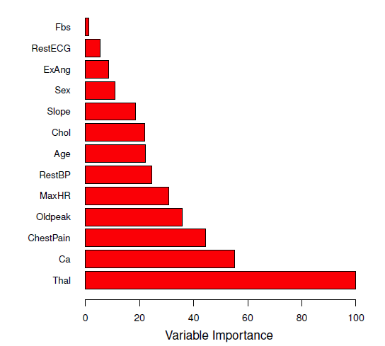

## Random forests

- A problem with bagging is that bagged trees may be **highly similar** to each other.
- For example, if there is a strong predictor in the data set, most of the bagged trees will **use this strong predictor** in the top split so that
  - the trees will look quite similar
  - predictions from the bagged trees will be highly correlated
- Averaging many highly correlated quantities does not lead to as large a reduction in variance as averaging many uncorrelated quantities

## Random forests: advantages over bagging

- Random forests overcome this problem by forcing each split to consider only a **subset** of the predictors (typically a random sample $m \approx \sqrt{p}$)
- Thus at each split, the algorithm is NOT ALLOWED to consider a majority of the available predictors (essentially $(p - m)/p$ of the splits will not even consider the strong predictor, giving other predictors a chance)
- This *decorrelates* the trees and makes the average of the resulting trees less variable (more reliable)
- Only difference between bagging and random forests is the choice of predictor subset size $m$ at each split: if a random forest is built using $m = p$ that's just bagging
- For both, we build a number of decision trees on bootstrapped training samples

## Example: Random forests versus bagging (gene expression data)

- High-dimensional biological data set: contains gene expression measurements of 4,718 genes measured on tissue samples from 349 patients
- Each of the patient samples has a qualitative label with 15 different levels: *Normal* or one of 14 different cancer types
- Want to predict cancer type based on the 500 genes that have the largest variance in the training set
- Randomly divided the observations into training/test and applied random forests (or bagging) to the training set for 3 different values of $m$ (the number of predictors available at each split)

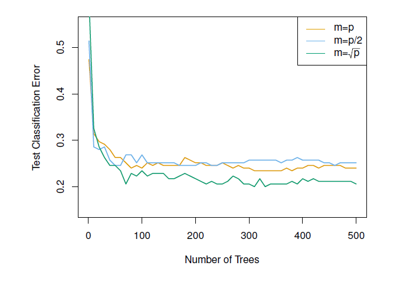

## Boosting

> **Boosting的核心思想**: 通过迭代地训练多个弱学习器（通常是决策树），每个学习器都专注于纠正前一个学习器的错误，从而将它们组合成一个强大的预测模型。
- Yet another approach to improve prediction accuracy from a decision tree
- Can also be applied to many statistical learning methods for regression or classification
- Recall that in bagging each tree is built on a bootstrap training data set
- In boosting, each tree is grown sequentially using information from previously grown trees:
  - given the current model, we fit a decision tree to the residuals of the model (rather than the outcome *Y*) as the response
  - we then add this new decision tree into the fitted function (model) in order to update the residuals
  - Why? this way each tree is built on information that the previous trees were unable to 'catch'

## Boosting Algorithm for Regression Trees

1. Initialize: $$ \hat{f}(x) = 0, \quad r_i = y_i \quad \text{for all } i \text{ in the training set}. $$
2. For $b = 1, 2, \ldots, B$, repeat the following steps:

   2.1 Fit a regression tree $\hat{f}^b$ with $d$ splits (i.e., $d + 1$ terminal nodes) to the training data $(X, r)$.

   2.2 Update the current model using a shrunken version of the new tree: $$ \hat{f}(x) \leftarrow \hat{f}(x) + \lambda \hat{f}^b(x) $$ where $\lambda \in (0, 1]$ is the learning rate (shrinkage parameter).

   2.3 Update the residuals: $$ r_i \leftarrow r_i - \lambda \hat{f}^b(x_i) $$
3. Output the final boosted model: $$ \hat{f}(x) = \sum_{b=1}^{B} \lambda \hat{f}^b(x) $$

where:

$\hat{f}(x)$ is the decision tree (model)

$r$ = residuals

$d$ = number of splits in each tree (controls the complexity of the boosted ensemble)

$\lambda$ = shrinkage parameter (a small positive number that controls the rate at which boosting learns; typically 0.01 or 0.001 but right choice can depend on the problem)

- Each of the trees can be small, with just a few terminal nodes (determined by $d$)
- By fitting small trees to the residuals, we slowly improve our model ($\hat{f}$) in areas where it doesn't perform well
- The shrinkage parameter $\lambda$ slows the process down further, allowing more and different shaped trees to 'attack' the residuals
- Unlike bagging and random forests, boosting can OVERFIT if $B$ is too large. $B$ is selected via cross-validation

### Example: Boosting vs. Random Forest

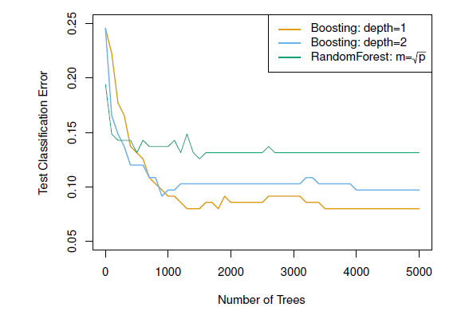

- Notice that because the growth of a particular tree takes into account the other trees that have already been grown, smaller trees are typically sufficient in boosting (versus random forests)
- Random forests and boosting are among the state-of-the-art methods for supervised learning (but, their results can be difficult to interpret)

## Bayesian Additive Regression Trees (BART)

### What is BART?

- BART is a **nonparametric Bayesian model** for regression and classification.
- It models the target variable as a **sum of many regression trees**: $$ y = \sum_{j=1}^{m} g(x; T_j, M_j) + \epsilon, \quad \epsilon \sim \mathcal{N}(0, \sigma^2) $$ where each tree $( T_j )$ and its terminal node parameters $( M_j )$ are drawn from a prior.

### Key Ideas

- **Sum-of-trees model**: Each individual tree makes a small contribution to the overall prediction.
- **Bayesian framework**: BART places priors over trees and uses MCMC to sample from the posterior.
- **Regularization via priors**:
  - Shallow trees encouraged (prevents overfitting).
  - Terminal node values shrunk toward zero.

### Advantages

- Captures **nonlinearities** and **interactions** automatically.
- Provides **uncertainty estimates** via posterior distributions.
- Performs well **out of the box**, with minimal tuning.
- Competitive with ensemble methods like **Random Forests** and **Boosting**.